# CLASSIFICATION OF ACTIVITY PERFORMANCE

## Abstract

This report trains models to classify barbell lifts into 5 different fashions. This data was obtained by having 6 young health participants perform one set of 10 repetitions of the Unilateral Dumbell Biceps Curl in five different fashions, classified as: A, B, C, D and E.

## Loading Data

Loading required R packages, and reading the provided training data set.

```r
library(caret)
library(rattle)
library(randomForest)
library(rpart.plot)

## Download and read the training and testing dataset
if(!file.exists("training")){
    dir.create("training")
}
fileUrl1 <- "https://d396qusza40orc.cloudfront.net/predmachlearn/pml-training.csv"
download.file(fileUrl1, destfile = "./training/training.csv", method = "curl")
training <- read.csv("./training/training.csv", sep = ",")
```

## Splitting Data into Training and Cross-Validation Set

I split the data into training and cross-validation set. I have put 70% of the data into the train set and 30% into the cross-validation set.

```r
inTrain <- createDataPartition(y=training$classe, p=0.7, list=FALSE)
train <- training[inTrain,]
cv <- training[-inTrain,]
```

## Pre-Processing the Data

Next I carry out some pre-processing on the train dataset. I remove the variables that have near zero variance and so will not vary between the classes. Then I calculate the fraction of missing data in each column.

```r
## remove nearZeroVar variables
nsv <- nearZeroVar(train, saveMetrics = FALSE)
train <- train[,-c(nsv)]

## Calculate the fraction of missing data in each column
miss <- c()
for(i in 1:ncol(train)){
    miss[i] <- sum(is.na(train[,i]))/nrow(train)
}

missing <- which(miss>0)

train <- train[,-missing]

train <- train[,-c(1:7)]
```

It was found that the columns with missing data had ~99% of the data missing, so I removed those columns. I also removed the first 7 columns which where just ID coulmns.

## Model Selection

First I trained a classification tree model, and calculated its accuracy in predicting the train set.

### Classification Tree

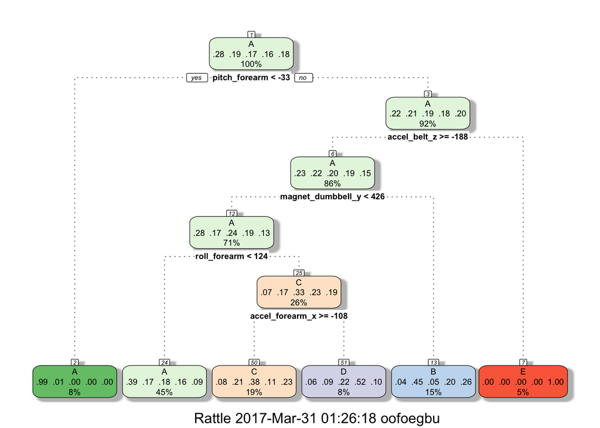

```r
set.seed(1334)
## Classification Tree
modFit <- train(classe ~., method= "rpart", data = train)
fancyRpartPlot(modFit$finalModel)
```

```r
predTrain <- predict(modFit)
confusionMatrix(predTrain, train$classe)
```

```
## Confusion Matrix and Statistics
##
##           Reference
## Prediction    A    B    C    D    E
##          A 3551 1082 1099 1008  550
##          B   84  949   96  423  552
##          C  204  528  964  276  577
##          D   65   98  237  545  109
##          E    2    1    0    0  737
##
## Overall Statistics
##
##                Accuracy : 0.4911
##                  95% CI : (0.4827, 0.4995)
##     No Information Rate : 0.2843
##     P-Value [Acc > NIR] : < 2.2e-16
##
##                   Kappa : 0.3344
##  Mcnemar's Test P-Value : < 2.2e-16
##
## Statistics by Class:
##
##                      Class: A Class: B Class: C Class: D Class: E
## Sensitivity            0.9091  0.35704  0.40234  0.24201  0.29188
## Specificity            0.6197  0.89575  0.86024  0.95568  0.99973
## Pos Pred Value         0.4871  0.45105  0.37819  0.51708  0.99595
## Neg Pred Value         0.9449  0.85309  0.87201  0.86541  0.86243
## Prevalence             0.2843  0.19349  0.17442  0.16394  0.18381
## Detection Rate         0.2585  0.06908  0.07018  0.03967  0.05365
## Detection Prevalence   0.5307  0.15316  0.18556  0.07673  0.05387
## Balanced Accuracy      0.7644  0.62639  0.63129  0.59884  0.64581
```

Using the classification tree model, the accuracy on the train set is ~50%. This is unacceptably low and so will not be used. Next I trained a randomForest model, and calculated its accuracy in predicting the train set.

### RandomForest

```r
## Random Forest
modFit2 <- randomForest(classe~., data=train)
predTrain2 <- predict(modFit2)
confusionMatrix(predTrain2, train$classe)
```

```
## Confusion Matrix and Statistics
##
##           Reference
## Prediction    A    B    C    D    E
##          A 3905   12    0    0    0
##          B    1 2641   16    0    1
##          C    0    5 2379   29    1
##          D    0    0    1 2222    9
##          E    0    0    0    1 2514
##
## Overall Statistics
##
##                Accuracy : 0.9945
##                  95% CI : (0.9931, 0.9956)
##     No Information Rate : 0.2843
##     P-Value [Acc > NIR] : < 2.2e-16
##
##                   Kappa : 0.993
##  Mcnemar's Test P-Value : NA
##
## Statistics by Class:
##
##                      Class: A Class: B Class: C Class: D Class: E
## Sensitivity            0.9997   0.9936   0.9929   0.9867   0.9956
## Specificity            0.9988   0.9984   0.9969   0.9991   0.9999
## Pos Pred Value         0.9969   0.9932   0.9855   0.9955   0.9996
## Neg Pred Value         0.9999   0.9985   0.9985   0.9974   0.9990
## Prevalence             0.2843   0.1935   0.1744   0.1639   0.1838
## Detection Rate         0.2843   0.1923   0.1732   0.1618   0.1830
## Detection Prevalence   0.2851   0.1936   0.1757   0.1625   0.1831
## Balanced Accuracy      0.9993   0.9960   0.9949   0.9929   0.9978
```

Using the randomForest model, the accuracy on the train set is ~99%. This is a very good accuracy, and so modFit2 is the best model for this data.

## Estimating model out-of-sample error

Using the cross validation set, and the best model (Random Forest, modFit2) I have calculated the expected accuracy of the model.

```r
cv <- cv[,-c(nsv)]
cv <- cv[,-missing]
cv <- cv[,-c(1:7)]

predcv <- predict(modFit2, cv)
confusionMatrix(predcv, cv$classe)
```

```
## Confusion Matrix and Statistics
##
##           Reference
## Prediction    A    B    C    D    E
##          A 1674    0    0    0    0
##          B    0 1138    0    0    0
##          C    0    1 1026    6    0
##          D    0    0    0  957    3
##          E    0    0    0    1 1079
##
## Overall Statistics
##
##                Accuracy : 0.9981
##                  95% CI : (0.9967, 0.9991)
##     No Information Rate : 0.2845
##     P-Value [Acc > NIR] : < 2.2e-16
##
##                   Kappa : 0.9976
##  Mcnemar's Test P-Value : NA
##
## Statistics by Class:
##
##                      Class: A Class: B Class: C Class: D Class: E
## Sensitivity            1.0000   0.9991   1.0000   0.9927   0.9972
## Specificity            1.0000   1.0000   0.9986   0.9994   0.9998
## Pos Pred Value         1.0000   1.0000   0.9932   0.9969   0.9991
## Neg Pred Value         1.0000   0.9998   1.0000   0.9986   0.9994
## Prevalence             0.2845   0.1935   0.1743   0.1638   0.1839
## Detection Rate         0.2845   0.1934   0.1743   0.1626   0.1833
## Detection Prevalence   0.2845   0.1934   0.1755   0.1631   0.1835
## Balanced Accuracy      1.0000   0.9996   0.9993   0.9961   0.9985
```

## Conclusion

This randomForest model can be used to predict a testing set with expected high accuracy.